# Day 8

## Review

#### Observational Studies

> An observational study is one in which we study something as it exists
- Observe individuals and measure variables of interest
  - Gather medical records to study relationship between smoking and heart disease

*Does NOT attempt to influence the response*

### Designed Experiments

> An experiment occurs when we control the conditions under which observations are taken
- Deliberately imposes treatments on individuals in order to observe response
  - Lab rats are given either a low carbohydrate diet or a high carbohydrate diet to see the effect on weight

*Does influence response*

**Experimental Unit:** Subject, animal, or object used in the experiment

**Treatment:** Experimental condition applied to experimental unit

**Response:** The thing we measure to determine the effect of the treatments

#### Confounding

Two variables in a study/experiment

- Effects are indistinguishable
- Can’t tell which variable caused an effect
- Observational studies don’t show causality
- Experiments can show causality
  - Typically have to have that intent designed into them

#### Collinearity

Two variables are linearly dependent

> “A form of extreme confounding”
- The variables contain the same information to an extent

#### Bias

> The design of statistical study is biased when one outcome is systematically preferred to others

*Impossible to correct for*

It is a systematic error caused by bad sampling design

#### Problems in Sampling

> Making up data is always bad

> Samples of convenience are easy, cheap, and easy to intentionally bias

> Voluntary response surveys can work well if designed well, but they’re very easy to design poorly

**Undercoverage**

**Nonresponse**

**Response Bias**

**Question Wording**

**Order of Questions**

#### Some Observational Study Types

**Case-control studies:**

A form of observational study that adjusts for this unique problem

- Select the case-subjects (those with the trait/condition) of interest
  - Take a random sample of those individuals
- Select a control group without the condition (ideally with similarities to the case subjects)
  - Take a random sample of those individuals

**Cohort Studies:**

**Subjects sharing a common demographic characteristic are enrolled and observed at regular intervals over an extended period of time**

- Starts with a group of similar individuals
- Observations made over regular intervals

**Questions?**

**Goals for Today:**

1. Quantify the strength of linear relationships
2. Introduce Least Squares Regression
3. Determine the age of the universe

## Correlation, Observation, and Regression

### Strength of Linear Relationship

- When two variables have a linear relationship
  - It’s useful to quantify how strong the relationship is
- Visual impressions aren’t really reliable
  - Axis scaling can change everything:

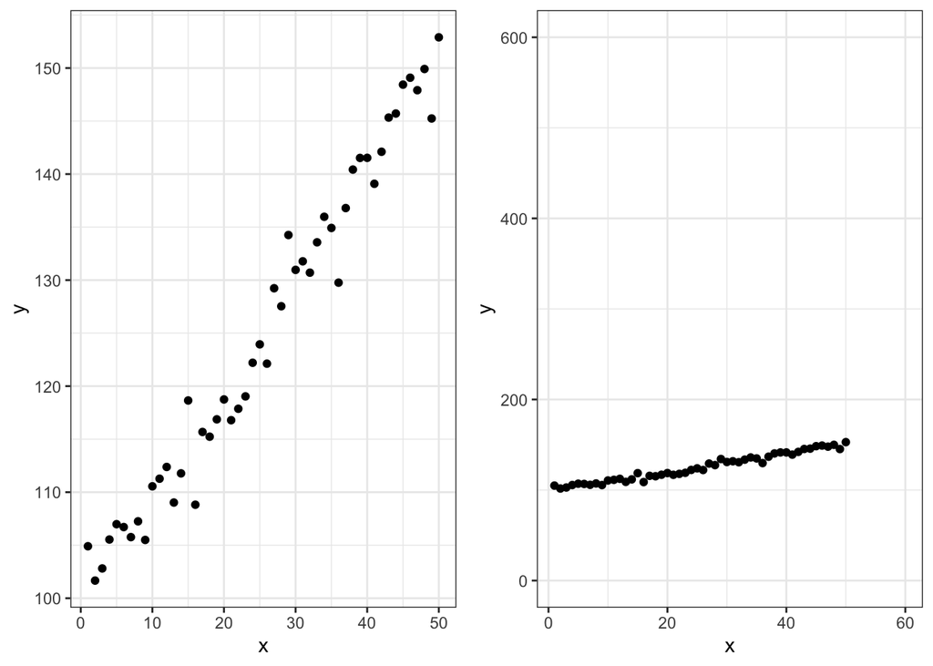

*Same exact data*

### Correlation Coefficient

**Numerical measurement of the strength (and direction) of the linear relationship between two quantitative variables**

- Given $n$ ordered pairs ($x_i,y_i$)
  - With sample means $\bar{x}$ and $\bar{y}$
  - Sample standard deviations $s_x$ and $s_y$
  - The correlation coefficient $r$ is given by:

$$r = \frac{1}{n-1} \sum_i \left( \frac{x_i - \bar{x}}{s_x} \right) \left( \frac{y_i - \bar{y}}{s_y} \right)$$

#### Properties of the Correlation Coefficient

1. The value is always between $-1 \le r \le 1$
- If $r=1$, all of the data falls on a line with a positive slope
- If $r=-1$ all of the data falls on a line with a negative slope
- The closer $r$ is to 0, the weaker the linear relationship between $x$ and $y$
- If $r=0$ *no linear relationship exists*
2. The correlation does not depend on the unit of measurement for the two variables
- $x$ is House price and $y$ is $ft^2$, but they can still have $r$ calculated
3. Correlation is very sensitive to outliers.
- One point that does not belong in the dataset can result in a misleading correlation
- Always plot your data!
- Would we say this measurement is resistant or not?
4. Correlation measures only the linear relationship and may not (by itself) detect a nonlinear relationship

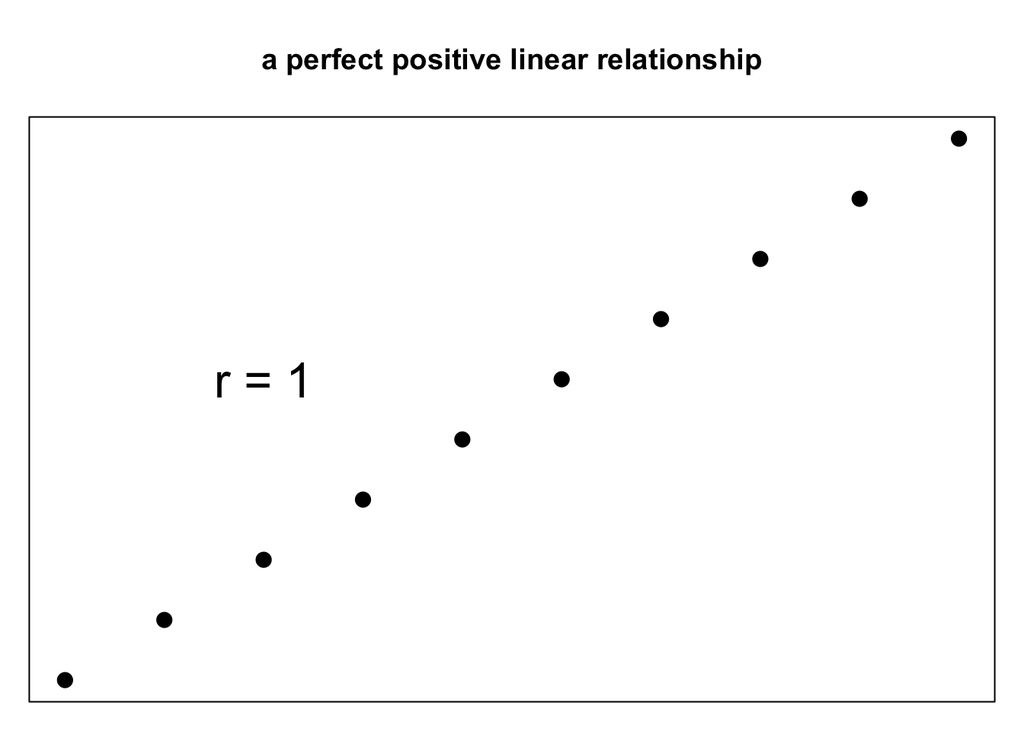

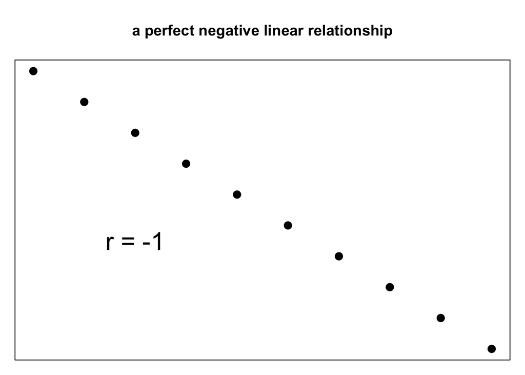

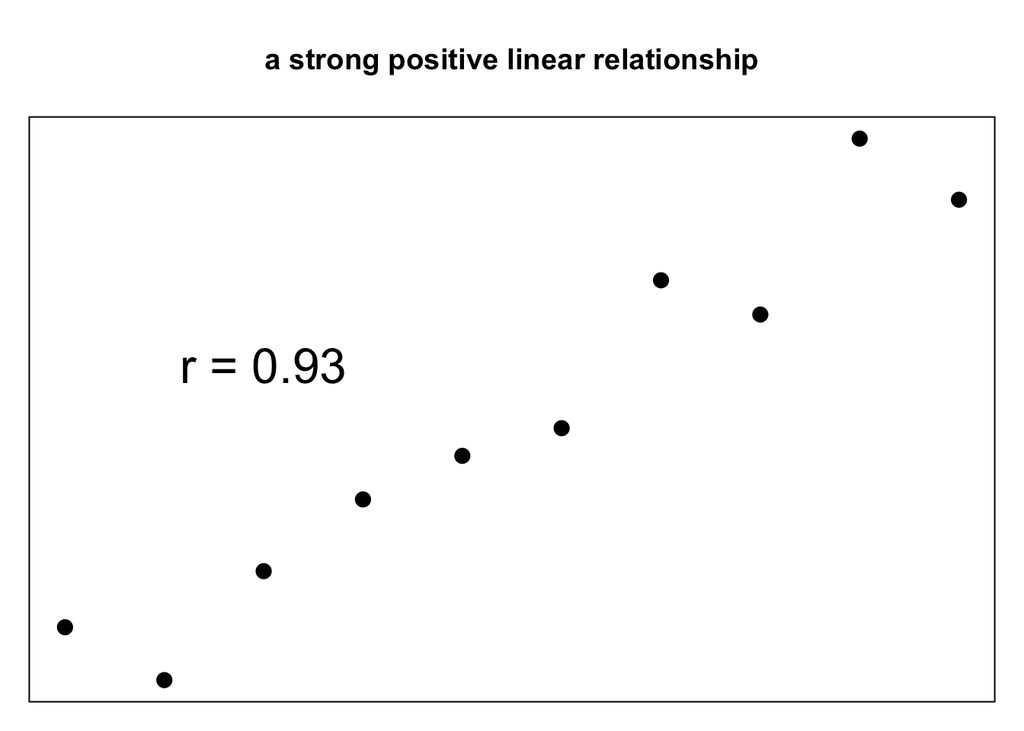

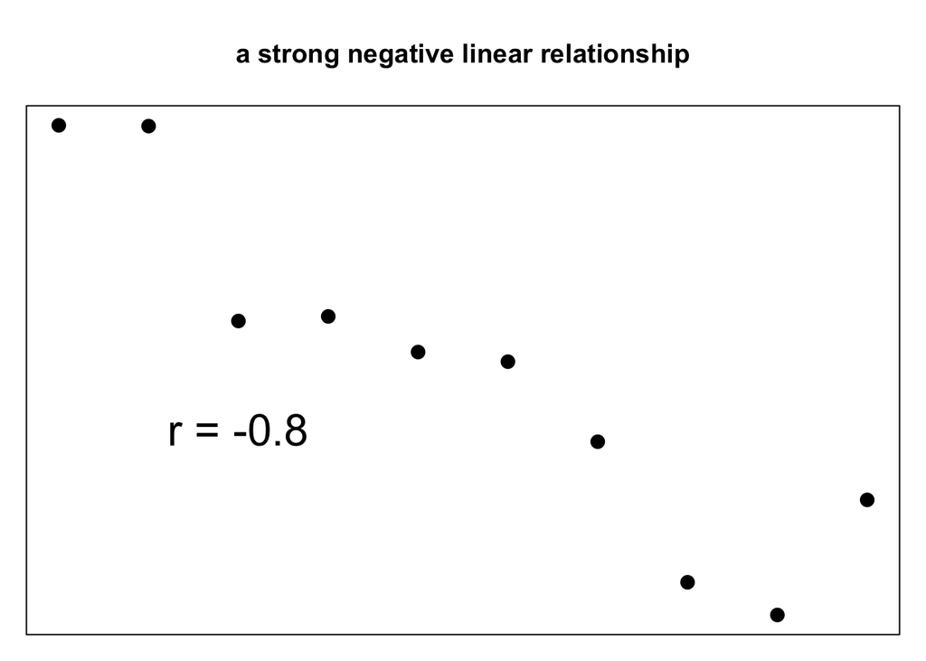

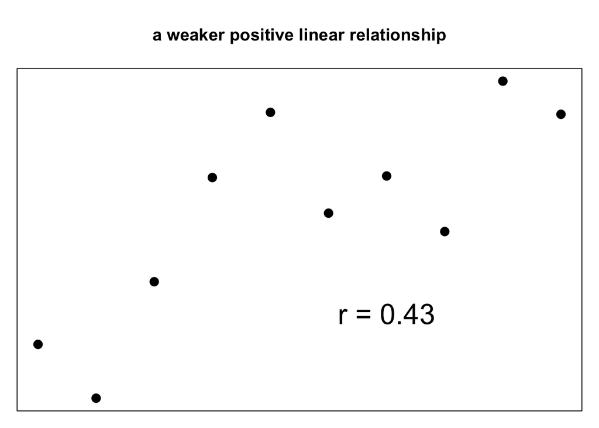

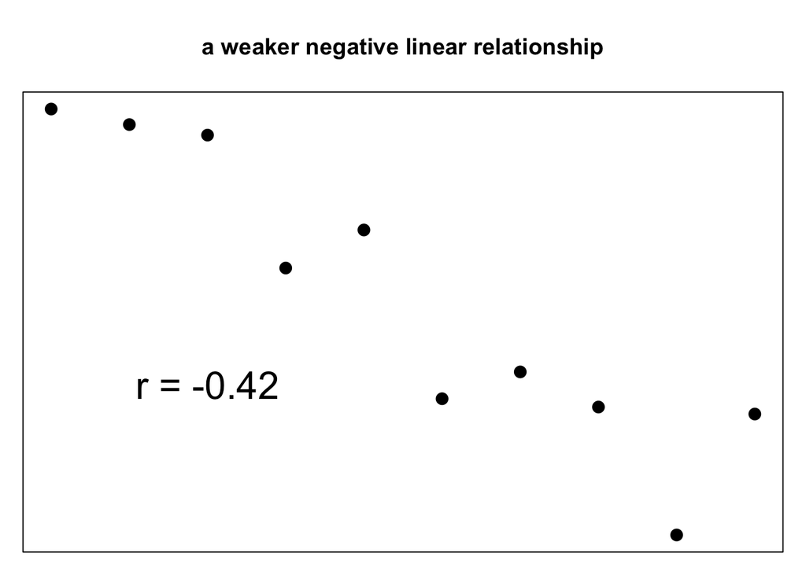

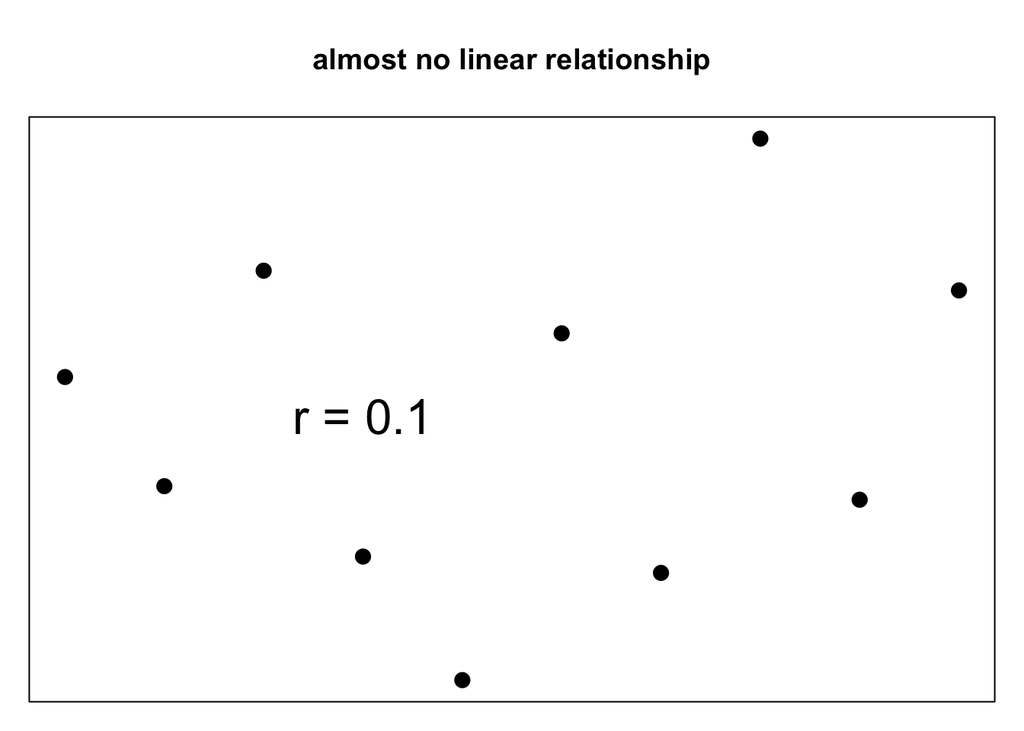

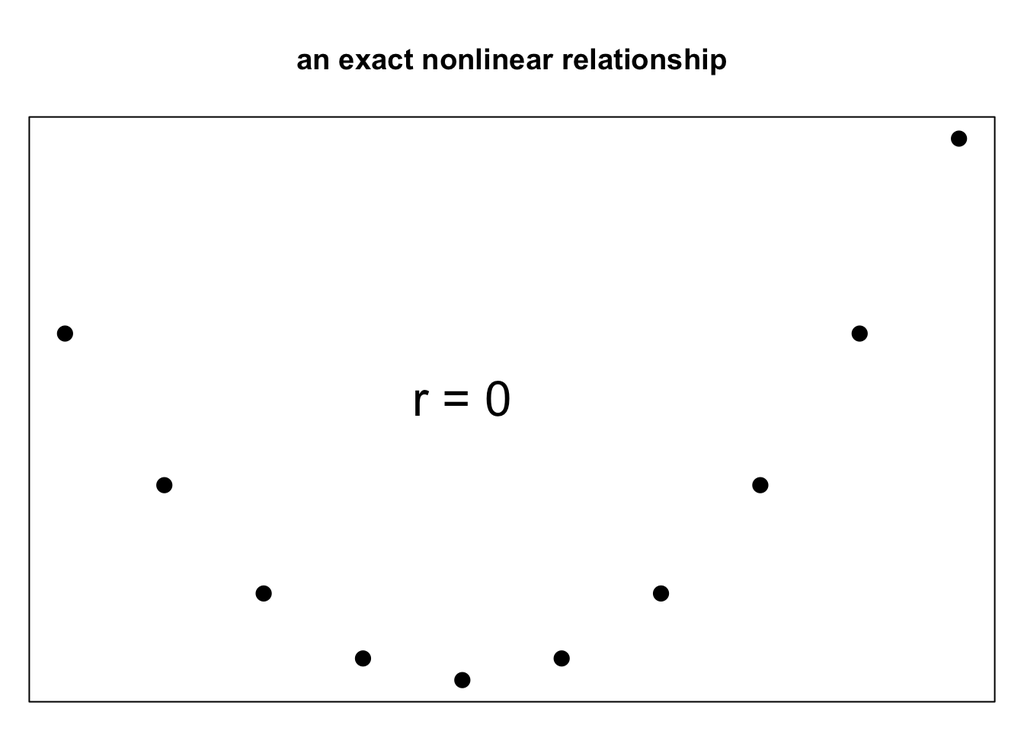

### Least-Squares Regression

**Recall our cholesterol example:**

**Two variables for each individual in the sample**

- $x=$ age of the patient
- $y=$ serum cholesterol level

For the $i^{th}$ patient, we’ll denote it’s observated values as:

- $x_i=$ the age of the $i^{th}$ patient in *years*
- $y_i=$ the serum cholesterol level of the $i^{th}$ patient in mmol/L

| Age | 67 | 52 | 57 | 56 | 60 | 42 | 58 | 53 | 52 | 39 | 54 | 50 | 62 | 38 | 54 | 48 | 64 | 69 | 53 | 62 |
| --- | --- | --- | --- | --- | --- | --- | --- | --- | --- | --- | --- | --- | --- | --- | --- | --- | --- | --- | --- | --- |
| Cholesterol | 229 | 196 | 241 | 283 | 253 | 265 | 218 | 282 | 205 | 219 | 304 | 196 | 263 | 175 | 214 | 245 | 325 | 239 | 264 | 209 |

The associated scatterplot:

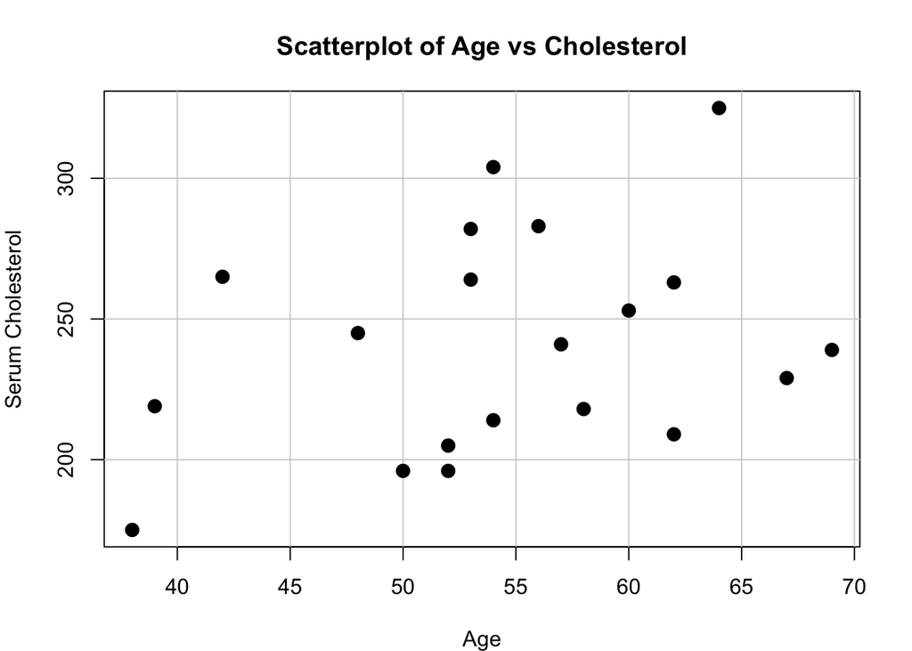

I’ve alluded in the past to the idea that we can **draw a line through these points:**

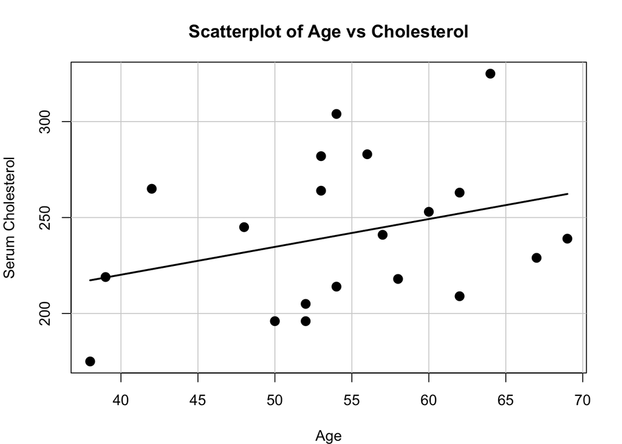

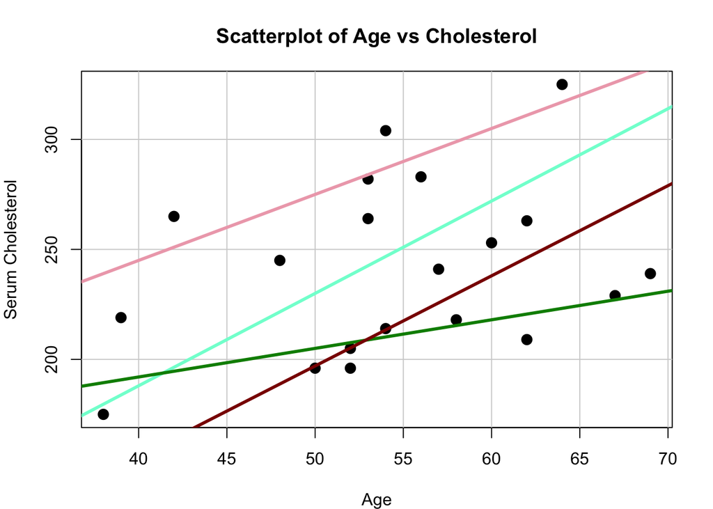

> **Why couldn’t these lines be viable ones for describing this data?**

> The vertical distances are from the points to the line are smaller for the first line

**We determine exactly how well the line fits by:**

- Squaring the vertical distances
- And adding them up

The “Best Fit” line is the line for which the **sum of squared distances** is as **small** as possible

This line is known as the **Least Squared Regression Line**

Given ordered pairs: ($x,y$)

- With sample means: $\bar{x}$ and $\bar{y}$
  - Sample standard deviations: $s_x$ and $s_y$
  - Correlation coefficient: $r$
  - The equation of the least-squared regression line for predicting $y$ from $x$ is:

$$\hat{y}=\beta_0+\beta_1x$$

Where the **slope** ($\beta_1$) is:

$$\beta_1 = r * {s_y\over s_x}$$

And the **intercept** ($\beta_0$) is:

$$\beta_0=\bar{y}-\beta_1 \bar{x}$$

- The variable we want to predict is the **outcome** or **response** variable
- And the variable we are given is the **explanatory** or **predictor** variable

> Let’s calculate the regression equation from our cholesterol example:

$$\bar{x}= 54.5,\ \bar{y}=241.25 ,\ s_x=8.49 ,\ s_y= 39.96,\ r=0.3163405$$

$$\beta_1 = r * {s_y\over s_x}$$

$$\beta_0=\bar{y}-\beta_1 \bar{x}$$

$$\hat{y}=\beta_0+\beta_1x$$

**Given our regression equation, predict the cholesterol level for your age**

## Interpretation of Least Squares Regression

- **Interpreting** the predicted $\hat{y}$
  - The predicted value of $\hat{y}$ can be used to estimate the average outcome for a given value of the explanatory variable $x$
  - For any given value of $x$, the value $\hat{y}$ is an estimate of the average $y$-value for all points with that $x$-value
- **Interpreting** $y$-intercept $b_0$
  - The y-intercept is $b_0$ is the point where the line crosses $y$-axis. This has two meanings
  - If the data has **both** positive and negative $x$-values the $y$-intercept is the estimated outcome when the value of explanatory variable is $0$

If the x-values are all positive or all negative then $b_0$ does **not** have useful information.

- **Interpreting** the slope $b_1$
  - If the x-values of two points differ by 1, their $y$-values will differ by an amount equal to the slope of the line

> At the final exam the professor asked each student to indicate how many hours they have studied for the exam
- The professor computes the least-square regression line for predicting the final exam scores from the number of hours studied

$$\hat{y} = 50 + 5x$$

- Antoine has studied for $6$ hours. What do you predict his score would be?
- Emma studied $3$ hours more than Jeremy did. How much higher do you predict Emma’s score to be?

> Is there an interpretation of the $y$-intercept?

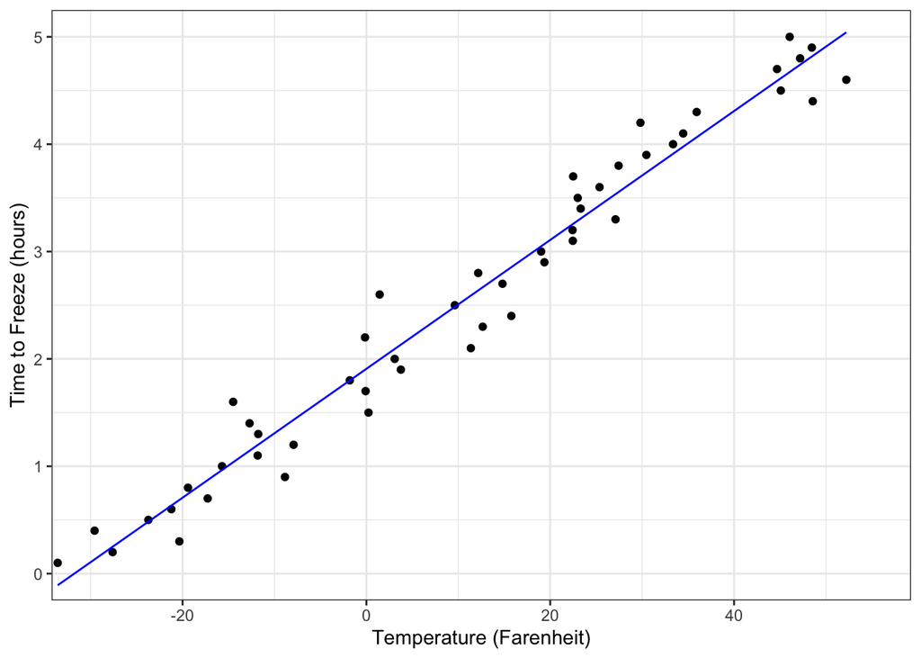

The least square regression line is $\hat{y} = 1.908 + 0.06x$ where $x$ is temperature in freezer in Fahrenheit and $y$ is the time it takes to freeze.

### Predicting the Age of the Universe with LSR

> Below is a plot of velocity against distance for 24 galaxies, according to measurements made using the Hubble Space Telescope - Credit: Wood 2006

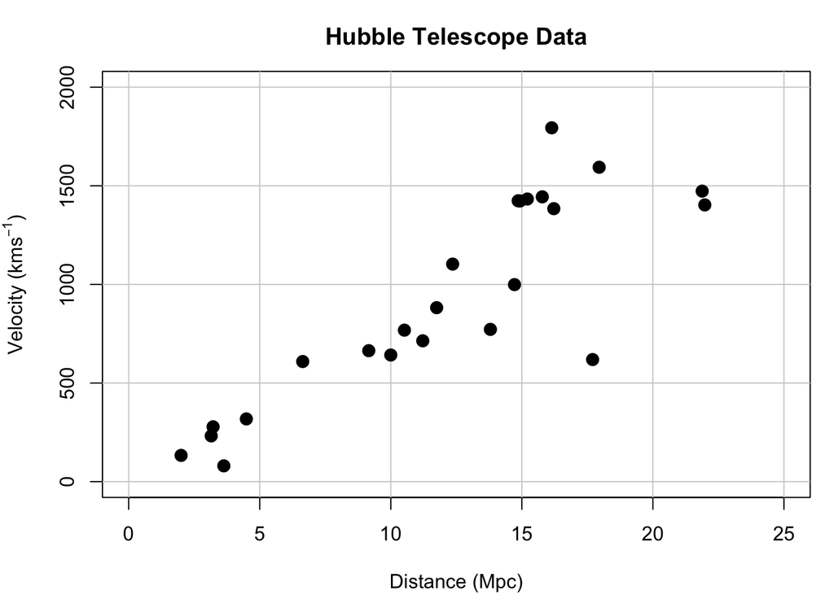

> Hubble’s Law states that galaxies are moving away from Earth at speeds proportional to their distance

**We can leverage this law to estimate the age of the Universe**

This is, in fact, the data we (the scientific community, humanity, etc.) used to for this estimation until horrifyingly recently

**Hubble Law:**

$$v=H_0D$$

$$v \rightarrow \text{Velocity}$$

$$D \rightarrow \text{Distance}$$

$$H_0 \rightarrow \text{Hubble's Constant}$$

**Hubble’s constant** is a *relative* *rate* of expansion (a.k.a. A slope)

By finding $H_0^{-1}$ and doing some unit conversions, we get a rough age of the universe

- Don’t worry, I’m making that part easier (it’s a lot of messy arithmetic on it’s own)

From this data we calculated the following values:

$$\begin{array}{|c|c|c|c|c|c|c|}
\hline
\text{n} & \bar{x} & \bar{y} & s_x & s_y & r\\
\hline
24 & 12.055 & 924.375 & 5.815 & 512.814 & 0.8632\\
\hline
\end{array}$$

1. Calculate $\beta_1$

$$\beta_1 = r * {s_y\over s_x}$$

2. Calculate $\beta_0$

$$\beta_0=\bar{y}-\beta_1 \bar{x}$$

3. Write out the Regression Equation

$$\hat{y}=\beta_0+\beta_1x$$

4. Compute the below formula:

$$979.708\over \beta_1$$

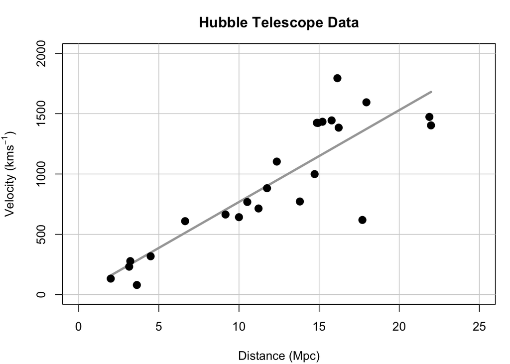